# 02_groceries_get_total_B

## 02_groceries_get_total_B

#### Question

1. Three people are buying fruit, and there are five grocery stores. Each person has a shopping list dictating how many pounds of each fruit to buy. Each store has different unit costs of fruit.

   In order to consider the **total** cost for each person at each store, we can use [matrix multiplication](https://en.wikipedia.org/wiki/Matrix_multiplication). In order to help visualize matrix multiplication, the shopping lists are shown as a matrix on the bottom-left, the unit prices as a matrix on top-right, and the resulting (unfilled) matrix of totals in the bottom-right.

   A peculiarity of matrix multiplication requires the **columns** of the first matrix to “match” the **rows** of the second matrix. In this case, notice the various fruits correspond to columns in the first matrix (bottom-left) and rows in the second matrix (top-right). This visualization is an attempt to make this seem more natural.

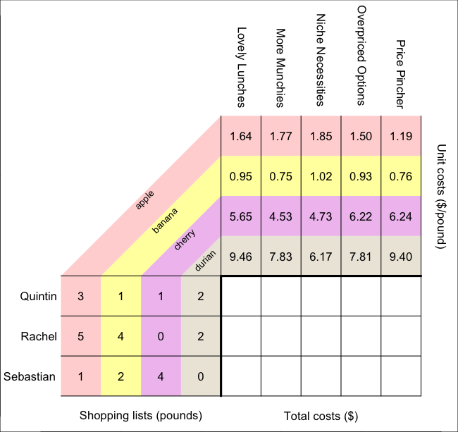

   What is the total cost of Sebastian shopping at Overpriced Options?

#### Question

2. Three people are buying fruit, and there are five grocery stores. Each person has a shopping list dictating how many pounds of each fruit to buy. Each store has different unit costs of fruit.

   In order to consider the **total** cost for each person at each store, we can use [matrix multiplication](https://en.wikipedia.org/wiki/Matrix_multiplication). In order to help visualize matrix multiplication, the shopping lists are shown as a matrix on the bottom-left, the unit prices as a matrix on top-right, and the resulting (unfilled) matrix of totals in the bottom-right.

   A peculiarity of matrix multiplication requires the **columns** of the first matrix to “match” the **rows** of the second matrix. In this case, notice the various fruits correspond to columns in the first matrix (bottom-left) and rows in the second matrix (top-right). This visualization is an attempt to make this seem more natural.

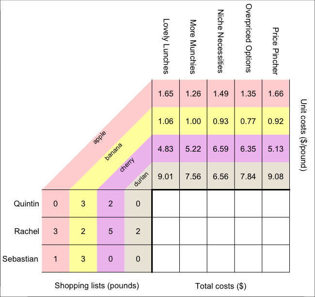

   What is the total cost of Quintin shopping at Niche Necessities?

#### Question

3. Three people are buying fruit, and there are five grocery stores. Each person has a shopping list dictating how many pounds of each fruit to buy. Each store has different unit costs of fruit.

   In order to consider the **total** cost for each person at each store, we can use [matrix multiplication](https://en.wikipedia.org/wiki/Matrix_multiplication). In order to help visualize matrix multiplication, the shopping lists are shown as a matrix on the bottom-left, the unit prices as a matrix on top-right, and the resulting (unfilled) matrix of totals in the bottom-right.

   A peculiarity of matrix multiplication requires the **columns** of the first matrix to “match” the **rows** of the second matrix. In this case, notice the various fruits correspond to columns in the first matrix (bottom-left) and rows in the second matrix (top-right). This visualization is an attempt to make this seem more natural.

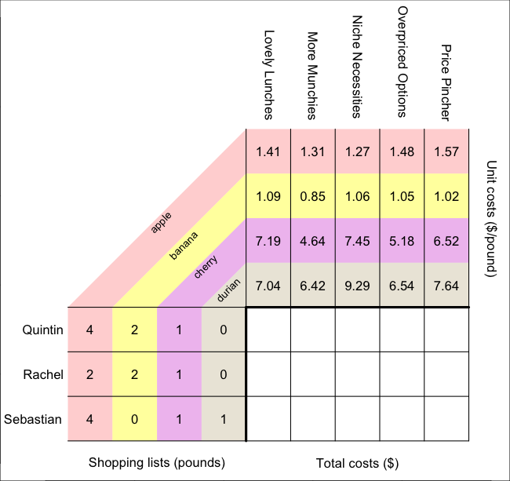

   What is the total cost of Rachel shopping at Lovely Lunches?

#### Question

4. Three people are buying fruit, and there are five grocery stores. Each person has a shopping list dictating how many pounds of each fruit to buy. Each store has different unit costs of fruit.

   In order to consider the **total** cost for each person at each store, we can use [matrix multiplication](https://en.wikipedia.org/wiki/Matrix_multiplication). In order to help visualize matrix multiplication, the shopping lists are shown as a matrix on the bottom-left, the unit prices as a matrix on top-right, and the resulting (unfilled) matrix of totals in the bottom-right.

   A peculiarity of matrix multiplication requires the **columns** of the first matrix to “match” the **rows** of the second matrix. In this case, notice the various fruits correspond to columns in the first matrix (bottom-left) and rows in the second matrix (top-right). This visualization is an attempt to make this seem more natural.

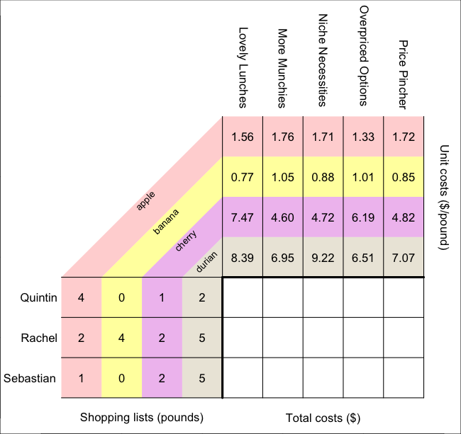

   What is the total cost of Sebastian shopping at Niche Necessities?

#### Question

5. Three people are buying fruit, and there are five grocery stores. Each person has a shopping list dictating how many pounds of each fruit to buy. Each store has different unit costs of fruit.

   In order to consider the **total** cost for each person at each store, we can use [matrix multiplication](https://en.wikipedia.org/wiki/Matrix_multiplication). In order to help visualize matrix multiplication, the shopping lists are shown as a matrix on the bottom-left, the unit prices as a matrix on top-right, and the resulting (unfilled) matrix of totals in the bottom-right.

   A peculiarity of matrix multiplication requires the **columns** of the first matrix to “match” the **rows** of the second matrix. In this case, notice the various fruits correspond to columns in the first matrix (bottom-left) and rows in the second matrix (top-right). This visualization is an attempt to make this seem more natural.

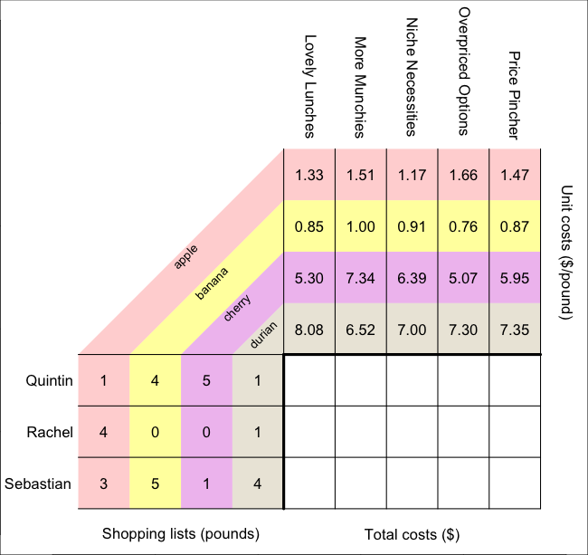

   What is the total cost of Quintin shopping at Lovely Lunches?

#### Question

6. Three people are buying fruit, and there are five grocery stores. Each person has a shopping list dictating how many pounds of each fruit to buy. Each store has different unit costs of fruit.

   In order to consider the **total** cost for each person at each store, we can use [matrix multiplication](https://en.wikipedia.org/wiki/Matrix_multiplication). In order to help visualize matrix multiplication, the shopping lists are shown as a matrix on the bottom-left, the unit prices as a matrix on top-right, and the resulting (unfilled) matrix of totals in the bottom-right.

   A peculiarity of matrix multiplication requires the **columns** of the first matrix to “match” the **rows** of the second matrix. In this case, notice the various fruits correspond to columns in the first matrix (bottom-left) and rows in the second matrix (top-right). This visualization is an attempt to make this seem more natural.

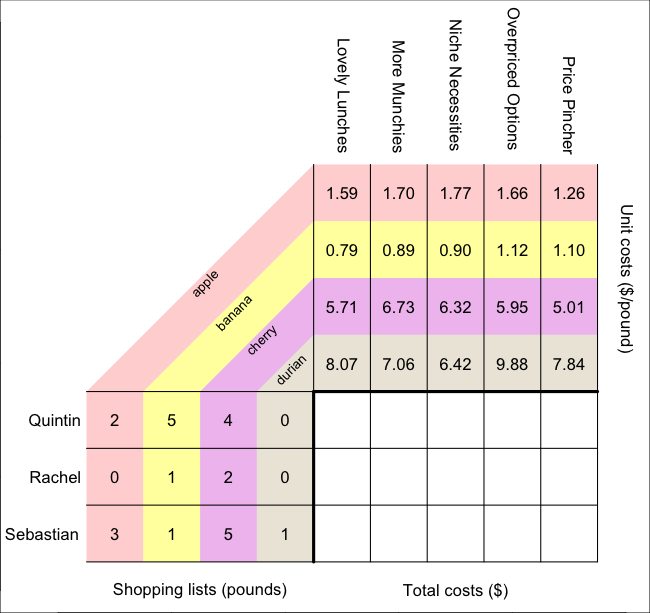

   What is the total cost of Quintin shopping at Lovely Lunches?

#### Question

7. Three people are buying fruit, and there are five grocery stores. Each person has a shopping list dictating how many pounds of each fruit to buy. Each store has different unit costs of fruit.

   In order to consider the **total** cost for each person at each store, we can use [matrix multiplication](https://en.wikipedia.org/wiki/Matrix_multiplication). In order to help visualize matrix multiplication, the shopping lists are shown as a matrix on the bottom-left, the unit prices as a matrix on top-right, and the resulting (unfilled) matrix of totals in the bottom-right.

   A peculiarity of matrix multiplication requires the **columns** of the first matrix to “match” the **rows** of the second matrix. In this case, notice the various fruits correspond to columns in the first matrix (bottom-left) and rows in the second matrix (top-right). This visualization is an attempt to make this seem more natural.

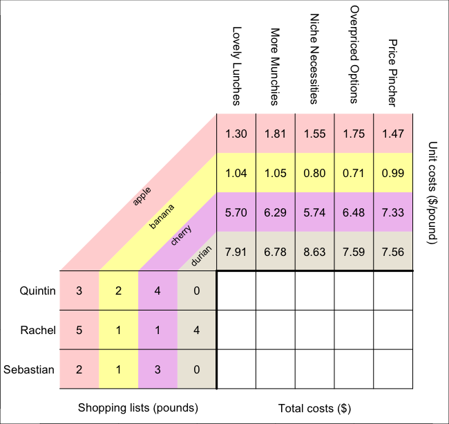

   What is the total cost of Quintin shopping at Niche Necessities?

#### Question

8. Three people are buying fruit, and there are five grocery stores. Each person has a shopping list dictating how many pounds of each fruit to buy. Each store has different unit costs of fruit.

   In order to consider the **total** cost for each person at each store, we can use [matrix multiplication](https://en.wikipedia.org/wiki/Matrix_multiplication). In order to help visualize matrix multiplication, the shopping lists are shown as a matrix on the bottom-left, the unit prices as a matrix on top-right, and the resulting (unfilled) matrix of totals in the bottom-right.

   A peculiarity of matrix multiplication requires the **columns** of the first matrix to “match” the **rows** of the second matrix. In this case, notice the various fruits correspond to columns in the first matrix (bottom-left) and rows in the second matrix (top-right). This visualization is an attempt to make this seem more natural.

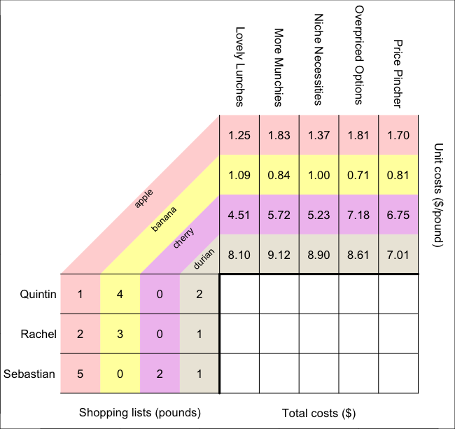

   What is the total cost of Sebastian shopping at Price Pincher?